# modelAndEDA FINAL pdf

### ROC and AUC performance comparison

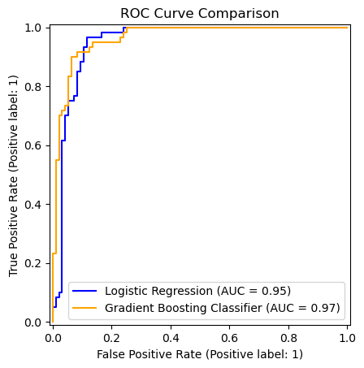

```python
from sklearn.metrics import RocCurveDisplay
logclf_roc_disp = RocCurveDisplay.from_estimator(logclf_top_perf, X_test, y_test, name="Logistic Regression", color='blue')
gbc_roc_disp = RocCurveDisplay.from_estimator(gbc_top_perf, X_test, y_test, name="Gradient Boosting Classifier", color='orange', ax=logclf_roc_disp.ax_)
logclf_roc_disp.ax_.set_title('ROC Curve Comparison')
plt.show()
```

```python
from sklearn.metrics import roc_auc_score
logclf_auc_roc = roc_auc_score(y_test, logclf_predictions)
print(f'Logistic Regression AUC ROC: {logclf_auc_roc}')
gbc_auc_roc = roc_auc_score(y_test, gbc_predictions)
print(f'Gradient Boosting Classifier AUC ROC: {gbc_auc_roc}')
```

```
Logistic Regression AUC ROC: 0.9156250000000001
Gradient Boosting Classifier AUC ROC: 0.91875
```

figure 27: ROC scores for both models

### Confusion Matrix Analysis

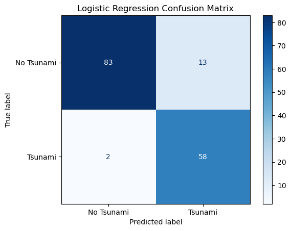

```python
from sklearn.metrics import ConfusionMatrixDisplay
logclf_cm_disp = ConfusionMatrixDisplay.from_estimator(logclf_top_perf, X_test, y_test, display_labels=['No Tsunami', 'Tsunami'], cmap='Blues')
logclf_cm_disp.ax_.set_title('Logistic Regression Confusion Matrix')
plt.show()
```

Figure 28: Logistic Regression Confusion Matrices

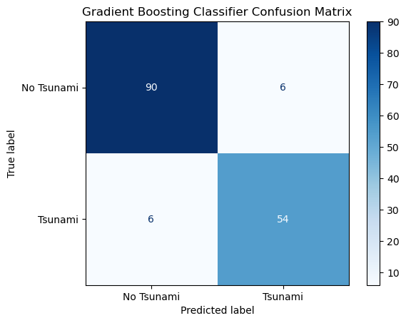

```python
gbc_cm_disp = ConfusionMatrixDisplay.from_estimator(gbc_top_perf, X_test, y_test, display_labels=['No Tsunami', 'Tsunami'], cmap='Blues')
gbc_cm_disp.ax_.set_title('Gradient Boosting Classifier Confusion Matrix')
plt.show()
```

figure 29: Confusion Matrices for Gradient Boosting Classifier

### Statistical Significance Testing

```python
from scipy.stats import ttest_rel
t_stat, p_value = ttest_rel(grid_searched_logclf_cross_val_scores, grid_searched_gbc_cross_val_scores)
print(f'T-statistic: {t_stat}, P-value: {p_value}')
if p_value < 0.05:
    print('The difference in model performance is statistically significant.')
else:
    print('The difference in model performance is not statistically significant.')
```

```
T-statistic: -2.2774092319489765, P-value: 0.04876866577246905
The difference in model performance is statistically significant.
```

Figure 30: T-Test Results Comparing Model CV Accuracies

### Model comparison summary

The results inform us that both models performed well on there training data, before and after hyperparameter tuning, achieving over 85% accuracy. Demostrating that both models understanding the underlying patterns of the data. The higher training score, 100%, of the gradient boosting classifier indicating it has a more developed understanding of the training data compared to logistic regression. It continued to marginally outperform logistic regression on test and validation data (figure 21) indicating its superior generalization capabilities. Yet the large gap between training and validation scores (figure 22) indicates greater overfitting compared to logistic regression.

Both models achieved similar precision, recall, and F1-scores (figures 24 and 25), indicating they are comparably effective at identifying tsunami events. Precsion was slightly higher for the gradient boosting classifier, showing it makes fewer false positive predictions. However, recall was marginally better for logistic regression, indicating it captures more true tsunami events. The higher F1-score of the gradient boosting classifier informs us a better balance between precision and recall overall, something that is vital for effective tsunami prediction to minimize both false alarms and missed events. Although minimally, the higher AUC of the gradient boosting classifier (figure 27) further supports its superior overall performance in distinguishing between tsunami and non-tsunami events across various classification thresholds.

The confusion matrices (figures 28 and 29) reveal that gradient boosting classifier makes fewer misclassifications overall compared to logistic regression, though it had slightly more false negatives, confirming the precision and recall results observed earlier. Our statistical significance testing on cross validation accuracies (figure 30), showed the gradient boosting classifier's accuracy advantage was statistically significant. This acknowledges a real performance difference between the models, this is important given marginal differences between the models accross most performance metrics.

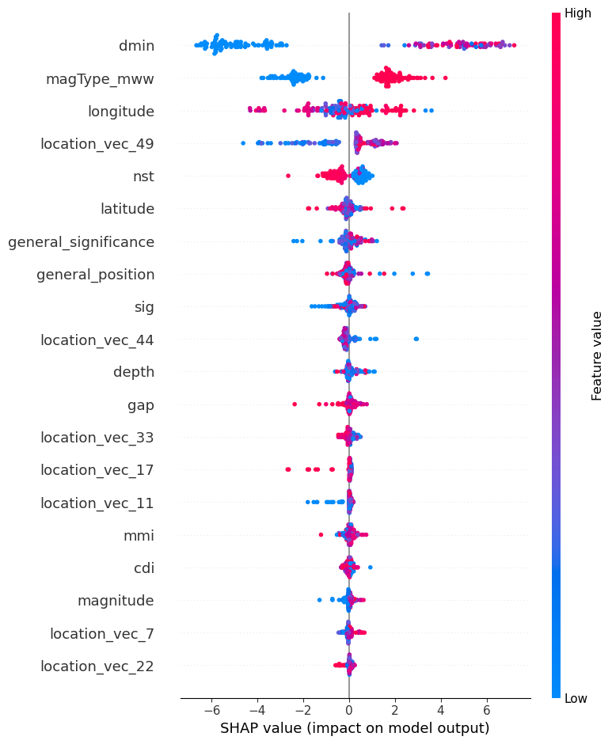

```python
explainer_gbc = shap.TreeExplainer(gbc_top_perf)
shap_values_gbc = explainer_gbc.shap_values(X_test)
shap.summary_plot(shap_values_gbc, X_test, plot_type='dot')
```

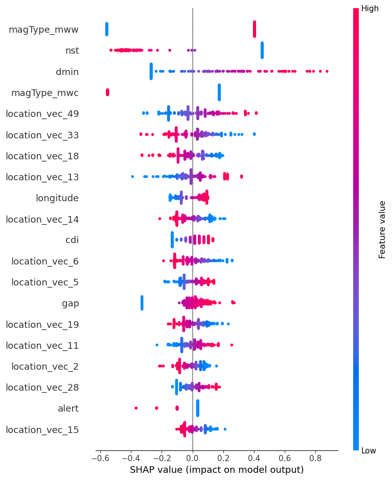

```python
explainer = shap.Explainer(logclf_top_perf, X_test)
shap_values = explainer(X_test)
shap.summary_plot(shap_values.values, X_test)
```

#### Research questions

`Will a gradient decsion boosting classifier outperform logistic regression in predicting tsunami occurrence following earthquakes based on seismic event characteristics?`

Based on our analysis, the gradient boosting classifier modestly outperformed logistic regression acrosss a majority of evaluation metrics, including accuracy, precision, F1-score, and ROC AUC scores. Logistic regression achieved a slightly higher recall score, indicating it may be better at identifying actual tsunami events. but the higher F1 score of the gradient boosting classifier suggests it is better overall at balancing false positives and false negatives. These finding are verified in statisical significance testing, which confirmed that the performance difference between the two models is statistically significant in favour of the gradient boosting classifier. Therefore, I conculude that the gradient boosting classifier is the better model for predicting tsunami occurrence following earthquakes based on seismic event characteristics.

`Which feature will be the most important predictor of tsunami occurrence following earthquakes?`

The SHAP summary plots inform us that `dmin` (horizontal distance from the epicenter to the nearest station) is the most important predictor of tsunami occurrence following earthquakes while `magtype` (total number of seismic stations used to determine earthquake location) is of highest important to the Logistic Regression model, the Gradient Boosting classifier achieved greater overall performance, so I conclude that `dmin` is the most important predictor overall. Although this may appear unconventional, the literature notes that the majority of seismic stations are located on land, meaning that earthquakes occurring further from land (higher `dmin` values) are more likely to be undersea events capable of generating tsunamis.

(Marra et al., 2017; United States Geological Survey, 2025)

The location text vectors also ranked highly in feature importance for both models, indicating that geographic patterns and seismic hotspots play a significant role in tsunami prediction. However, `dmin` has a more direct relationship with tsunami occurrence, making it the most important predictor overall.

## Novelty

The primary novelty of this project lies in incorporating textual location data through Word2Vec embeddings, distinguishing it from conventional tsunami prediction models that rely heavily on numerical seismic parameters (Mulia et al., 2022). While traditional approaches use only values such as: coordinates, magnitude, and depth, I extracted semantic patterns from unstructured earthquake location descriptions using pre-trained embeddings. To manage dimensionality constraints given our small dataset, I averaged word vectors rather than concatenating them, producing fixed 50 representations that preserve semantic meaning without massive feature expansion. This text based feature encoding complements our unqiue imputation strategies, all of which helped achieve a highly performant model despite the limited dataset size.

## Reflection

This project enhanced my understanding of machine learning through practical challenges I encountered. My model comparison revealed through various metrics that the performance tradeoff where logistic regression's simplicity versus gradient boostings complexity showed algorithmic sophistication doesn't guarantee proportional gains.

A significant challenge I faced was addressing extreme outliers through logarithmic transformations, new to my experience. I was aware that outliers could skew model training and degrade performance, so I applied the log1p transformation to normalize skewed distributions while preserving zero values. SHAP analysis revealed models prioritized instrumental factors (`dmin`) over traditional seismic characteristics, challenging my initial assumptions and emphasizing data driven feature importance. Through systematic hyperparameter optimization I reinforced iterative model development, with cross validation proving essential for robust performance estimation. This experience shifted my approach from algorithm centered implementation toward comprehensive problem solving encompassing data quality, feature engineering, and model interpretability.

# References:

Chauhan, C. (2025) Earthquake dataset. Kaggle. Available from: https://www.kaggle.com/datasets/warcoder/earthquake-dataset?select=earthquake_data.csv [Accessed 24 October 2025].

United States Geological Survey (USGS) (no date) Earthquake Hazards Program Glossary. U.S. Geological Survey. Available from: https://www.usgs.gov/glossary/earthquake-hazards-program [Accessed 26 October 2025].

CDI Wald, D.J., Quitoriano, V., Worden, C.B., Hopper, M. and Dewey, J.W. (2011) ‘USGS “Did You Feel It?”: Internet-based macroseismic intensity maps’, Annals of Geophysics, 54(6), pp. 688–707. Available from: https://www.researchgate.net/publication/268368064_USGS_Did_You_Feel_It_Internet-based_macroseismic_intensity_maps [Accessed 26 October 2025].

United States Geological Survey (USGS) (1989) Modified Mercalli Intensity Scale. U.S. Geological Survey. Available from: https://www.usgs.gov/programs/earthquake-hazards/modified-mercalli-intensity-scale [Accessed 26 October 2025].

United States Geological Survey (USGS) (2010) PAGER Scientific Background. U.S. Geological Survey. Available from: https://earthquake.usgs.gov/data/pager/background.php [Accessed 26 October 2025].

itdxer (2017) ‘What does average of word2vec vector mean?’, Cross Validated – Statistics Stack Exchange, 14 December. Available from: https://stats.stackexchange.com/questions/318882/what-does-average-of-word2vec-vector-mean%5BAccessed 3 November 2025].

United States Geological Survey (2022) Why is the earthquake that was reported/recorded by network X, or that I felt, not on the Latest Earthquakes map/list? Available from: https://www.usgs.gov/faqs/why-earthquake-was-reportedrecorded-network-x-or-i-felt-not-latest-earthquakes-maplist [Accessed 3 November 2025]

A l w a y s S u n n y, 2019. pandas convert from datetime to integer timestamp Stack Overflow. Available at: https://stackoverflow.com/questions/54312802/pandas-convert-from-datetime-to-integer-timestamp [Accessed 4 Nov. 2025].

GeeksforGeeks, 2025. Feature Importance with Random Forests Available at: https://www.geeksforgeeks.org/machine-learning/feature-importance-with-random-forests [Accessed 4 November 2025].

ChatGPT, 2025. General multi-use session. Available at: https://chatgpt.com/c/6909a310-4050-832b-94b1-35a82b81cec3 [Accessed 7-15th November 2025].

Blagus, R. & Lusa, L., 2013. SMOTE for high-dimensional class-imbalanced data. BMC Bioinformatics, 14, p.106. Available at: https://bmcbioinformatics.biomedcentral.com/articles/10.1186/1471-2105-14-106 [Accessed 5 November 2025].

Huang, X., Khetan, A., Cvitkovic, M., & Karnin, Z. (2020). TabTransformer: Tabular Data Modeling Using Contextual Embeddings. Available at: https://doi.org/10.48550/arXiv.2012.06678 (Accessed: 13 November 2025).

Lomax, A., Michelini, A. and Piatanesi, A., 2011. An assessment of rapid magnitude and tsunami potential estimation for shallow earthquakes. Available at: https://academic.oup.com/gji/article/185/1/283/602131 (Accessed: 13 November 2025).

United States Geological Survey (USGS) 2023, Tsunamis and tsunami-hazards, U.S. Geological Survey https://www.usgs.gov/water-science-school/science/tsunamis-and-tsunami-hazards. (Accessed: 13 November 2025).

Google LLC (2025) Class‑imbalanced datasets. Google Developers, viewed 13 November 2025, https://developers.google.com/machine-learning/crash-course/overfitting/imbalanced-datasets. (Accessed: 13 November 2025).

Wainwright, M. J., Ravikumar, P. & Lafferty, J. D. (2006) High‑Dimensional Graphical Model Selection Using Regularized Logistic Regression. Neural Information Processing Systems Foundation. Available at: https://proceedings.neurips.cc/paper_files/paper/2006/file/86b20716fbd5b253d27cec43127089bc-Paper.pdf (Accessed: 13 November 2025).

Ayer, T., Chhatwal, J., Alagoz, O., Kahn, C. E. Jr., Woods, R. W. & Burnside, E. S. (2010) ‘Informatics in Radiology: Comparison of Logistic Regression and Artificial Neural Network Models in Breast Cancer Risk Estimation’. Available at: https://www.ncbi.nlm.nih.gov/pmc/articles/PMC3709515 (Accessed: 14 November 2025).

Lee, F. (2025) What is logistic regression? IBM. Available at: https://www.ibm.com/think/topics/logistic-regression (Accessed: 13 November 2025).

Friedman, J.H., 1999. Greedy function approximation: A gradient boosting machine. Available at: https://projecteuclid.org/journals/annals-of-statistics/volume-29/issue-5/Greedy-function-approximation-A-gradient-boosting-machine/10.1214/aos/1013203451.full (Accessed: 14 November 2025).

Natekin, A. & Knoll, A., 2013. Gradient boosting machines, a tutorial. Frontiers in Neurorobotics. Available at: https://www.ncbi.nlm.nih.gov/pmc/articles/PMC3885826/ [Accessed 13 November 2025].

Luo, J., Yuan, Y. & Xu, S., 2024. Improving GBDT Performance on Imbalanced Datasets: An Empirical Study of Class‑Balanced Loss Functions. Available at: https://doi.org/10.48550/arXiv.2407.14381 (Accessed: 13 November 2025).

Peter, S., Diego, F., Hamprecht, F.A. & Nadler, B., 2017. Cost efficient gradient boosting. Available at: https://papers.nips.cc/paper/6753-cost-efficient-gradient-boosting.pdf (Accessed: 13 November 2025).

Matplotlib (no date) Matplotlib. Available from: https://matplotlib.org/stable/gallery/pie_and_polar_charts/pie_features.html [Accessed 3 November 2025].

Marra, G. et al. (2017) ‘Seismology with optical links: enabling a global network for submarine earthquake monitoring’. Available at: https://arxiv.org/abs/1801.02698 (Accessed: 26 November 2025).

United States Geological Survey (USGS) (2025) What is it about an earthquake that causes a tsunami? Available at: https://www.usgs.gov/faqs/what-it-about-earthquake-causes-a-tsunami (Accessed: 26 November 2025).

Mulia, I.E. et al., 2022. Machine learning-based tsunami inundation prediction derived from offshore observations. Nature Communications, 13, p.5489. Available at: https://www.nature.com/articles/s41467-022-33253-5 [Accessed 5 November 2025].

Aburass, S. (2023) Quantifying Overfitting: Introducing the Overfitting Index. arXiv. Available from: https://arxiv.org/abs/2308.08682 (Accessed: 28 November 2025).

# Appendix

## AI Usage Disclosure

All code generated by AI was carefully checked using my own knowledge of programming from a career in software development as well as cross referncing with online searches and documentation to ensure accuracy and appropriateness for the task at hand.

**All AI generated code is marked with a reference to (ChatGPT, 2025)**

Queries used:

- "Write a Python snippet using pandas and numpy that applies a log transformation to a subset of columns in a dataframe. The code should select a group of columns and apply np.log1p to each value in those columns in a vectorized way"
- "make a bit of python using pandas and matplotlib that takes a dataset of features and a separate dataset of feature importances selects a group of features based on a common naming pattern calculates the total importance of that feature group takes the importance of one individual feature and visualizes the comparison with a bar chart"
- "use matplotlib that adjusts the y-axis limits of a matplotlib plot to zoom in on a specific range so that small differences are more visible" templated code reused in different places
- 'Given python matplotlib code X highlight the highest bar in the chart' - templated code reused in different places'
- "python code using matplotlib that creates a grouped bar chart comparing two sets of numeric values the code should plot the bars side by side with different colors and labels, and annotate each bar with its exact height value on top" templated code reused in different places

**All of these queries produced code snippets that were then adapted significantly and integrated into the project as appropriate.**

I also used AI to format my references correctly from a rough list of sources into proper Harvard referencing style.

Multi use chatgpt session used (ChatGPT, 2025) in order to store keep track of all queries and responses - https://chatgpt.com/c/6909a310-4050-832b-94b1-35a82b81cec3